# Explore and Summarize Red Wine Data by Luis Cruz

In this project a wine dataset is used. It is related to red variant of the Portuguese "Vinho Verde" wine. The data is available [here](https://s3.amazonaws.com/udacity-hosted-downloads/ud651/wineQualityReds.csv). A description of this dataset can be found [here](https://s3.amazonaws.com/udacity-hosted-downloads/ud651/wineQualityInfo.txt).

According to this description there are no Null values. A description of the attributes is also given:

1 - **fixed acidity** (tartaric acid - g / dm^3): most acids involved with wine or fixed or nonvolatile (do not evaporate readily)

2 - **volatile acidity** (acetic acid - g / dm^3): the amount of acetic acid in wine, which at too high of levels can lead to an unpleasant, vinegar taste

3 - **citric acid** (g / dm^3): found in small quantities, citric acid can add 'freshness' and flavor to wines

4 - **residual sugar** (g / dm^3): the amount of sugar remaining after fermentation stops, it's rare to find wines with less than 1 gram/liter and wines with greater than 45 grams/liter are considered sweet

5 - **chlorides** (sodium chloride - g / dm^3): the amount of salt in the wine

6 - **free sulfur dioxide** (mg / dm^3): the free form of SO2 exists in equilibrium between molecular SO2 (as a dissolved gas) and bisulfite ion; it prevents microbial growth and the oxidation of wine

7 - **total sulfur dioxide** (mg / dm^3): amount of free and bound forms of S02; in low concentrations, SO2 is mostly undetectable in wine, but at free SO2 concentrations over 50 ppm, SO2 becomes evident in the nose and taste of wine

8 - **density** (g / cm^3): the density of water is close to that of water depending on the percent alcohol and sugar content

9 - **pH**: describes how acidic or basic a wine is on a scale from 0 (very acidic) to 14 (very basic); most wines are between 3-4 on the pH scale

10 - **sulphates** (potassium sulphate - g / dm3): a wine additive which can contribute to sulfur dioxide gas (S02) levels, which acts as an antimicrobial and antioxidant

11 - **alcohol** (% by volume): the percent alcohol content of the wine

12 - **quality** (score between 0 and 10) -- **Output variable (based on sensory data)**

### Dataset Overview

```r
## [1] 1599   13
```

```r
##  [1] "X"                    "fixed.acidity"        "volatile.acidity"
##  [4] "citric.acid"          "residual.sugar"       "chlorides"
##  [7] "free.sulfur.dioxide"  "total.sulfur.dioxide" "density"
## [10] "pH"                   "sulphates"            "alcohol"
## [13] "quality"
```

```r
## 'data.frame':   1599 obs. of  13 variables:
##  $ X                   : int  1 2 3 4 5 6 7 8 9 10 ...
##  $ fixed.acidity       : num  7.4 7.8 7.8 11.2 7.4 7.4 7.9 7.3 7.8 7.5 ...
##  $ volatile.acidity    : num  0.7 0.88 0.76 0.28 0.7 0.66 0.6 0.65 0.58 0.5 ...
##  $ citric.acid         : num  0 0 0.04 0.56 0 0 0.06 0 0.02 0.36 ...
##  $ residual.sugar      : num  1.9 2.6 2.3 1.9 1.9 1.8 1.6 1.2 2 6.1 ...
##  $ chlorides           : num  0.076 0.098 0.092 0.075 0.076 0.075 0.069 0.065 0.073 0.071 ...
##  $ free.sulfur.dioxide : num  11 25 15 17 11 13 15 15 9 17 ...
##  $ total.sulfur.dioxide: num  34 67 54 60 34 40 59 21 18 102 ...
##  $ density             : num  0.998 0.997 0.997 0.998 0.998 ...
##  $ pH                  : num  3.51 3.2 3.26 3.16 3.51 3.51 3.3 3.39 3.36 3.35 ...
##  $ sulphates           : num  0.56 0.68 0.65 0.58 0.56 0.56 0.46 0.47 0.57 0.8 ...
##  $ alcohol             : num  9.4 9.8 9.8 9.8 9.4 9.4 9.4 10 9.5 10.5 ...
##  $ quality             : int  5 5 5 6 5 5 5 7 7 5 ...
```

```r
##        X          fixed.acidity   volatile.acidity  citric.acid
##  Min.   :   1.0   Min.   : 4.60   Min.   :0.1200   Min.   :0.000
##  1st Qu.: 400.5   1st Qu.: 7.10   1st Qu.:0.3900   1st Qu.:0.090
##  Median : 800.0   Median : 7.90   Median :0.5200   Median :0.260
##  Mean   : 800.0   Mean   : 8.32   Mean   :0.5278   Mean   :0.271
##  3rd Qu.:1199.5   3rd Qu.: 9.20   3rd Qu.:0.6400   3rd Qu.:0.420
##  Max.   :1599.0   Max.   :15.90   Max.   :1.5800   Max.   :1.000
##  residual.sugar     chlorides       free.sulfur.dioxide
##  Min.   : 0.900   Min.   :0.01200   Min.   : 1.00
##  1st Qu.: 1.900   1st Qu.:0.07000   1st Qu.: 7.00
##  Median : 2.200   Median :0.07900   Median :14.00
##  Mean   : 2.539   Mean   :0.08747   Mean   :15.87
##  3rd Qu.: 2.600   3rd Qu.:0.09000   3rd Qu.:21.00
##  Max.   :15.500   Max.   :0.61100   Max.   :72.00
##  total.sulfur.dioxide    density             pH          sulphates
##  Min.   :  6.00       Min.   :0.9901   Min.   :2.740   Min.   :0.3300
##  1st Qu.: 22.00       1st Qu.:0.9956   1st Qu.:3.210   1st Qu.:0.5500
##  Median : 38.00       Median :0.9968   Median :3.310   Median :0.6200
##  Mean   : 46.47       Mean   :0.9967   Mean   :3.311   Mean   :0.6581
##  3rd Qu.: 62.00       3rd Qu.:0.9978   3rd Qu.:3.400   3rd Qu.:0.7300
##  Max.   :289.00       Max.   :1.0037   Max.   :4.010   Max.   :2.0000
##     alcohol         quality
##  Min.   : 8.40   Min.   :3.000
##  1st Qu.: 9.50   1st Qu.:5.000
##  Median :10.20   Median :6.000
##  Mean   :10.42   Mean   :5.636
##  3rd Qu.:11.10   3rd Qu.:6.000
##  Max.   :14.90   Max.   :8.000
```

This overview shows that all the attributes are numerical. Also we can see that the wines in this study have relatively low alcohol, since 75% of wines have between 8.40 and 11.10 by volume. This is a common feature in this kind of wine, "Vinho Verde". Properties such as **residual.sugar**, **chlorides**, **free.sulfur.dioxide** and **total.sulfur.dioxide** seem to have outliers since the maximum is much higher than the 75% percentile.

# Univariate Plots Section

### Quality

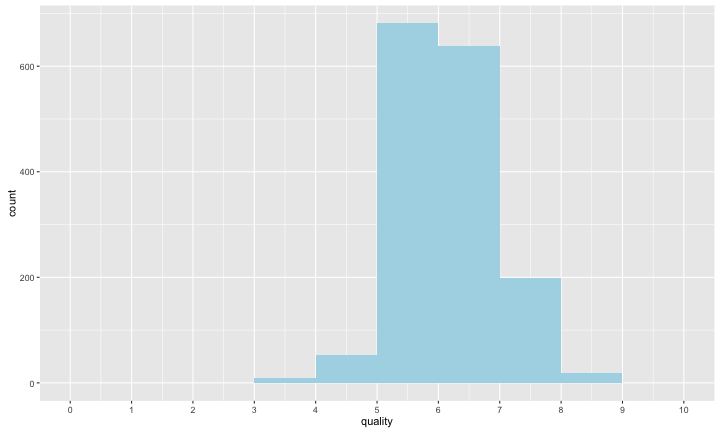

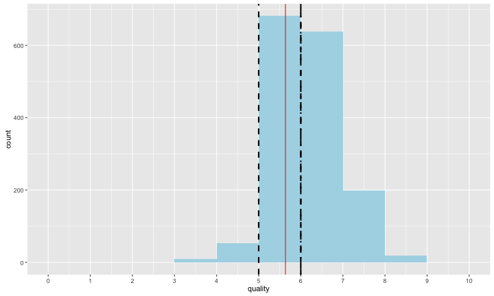

### Alcohol

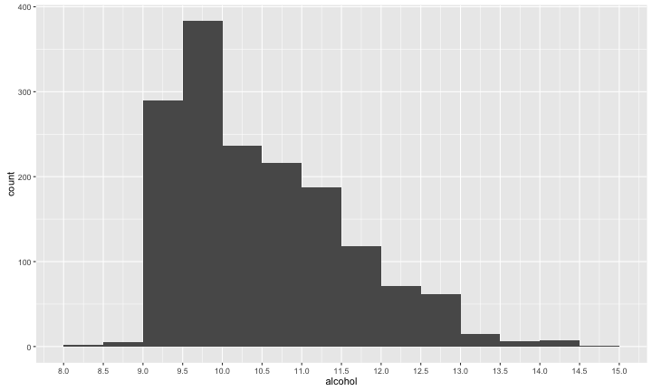

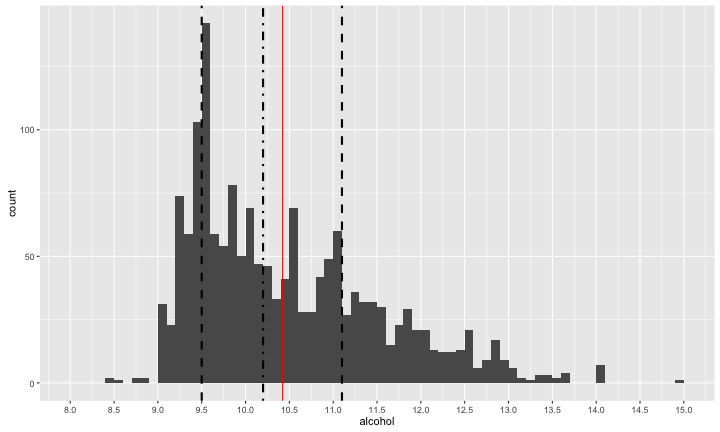

There are some outliers below 9% and above 14% alcohol by volume. Most wines are between 9% and 12%.

### pH

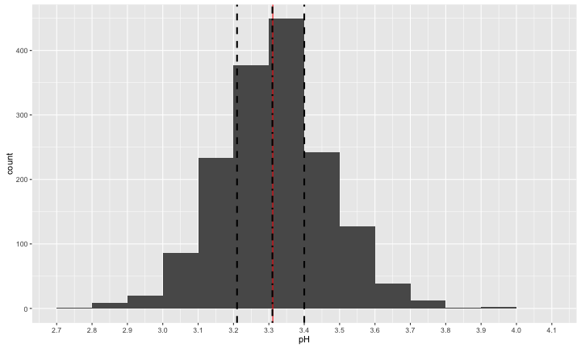

## Fixed acidity

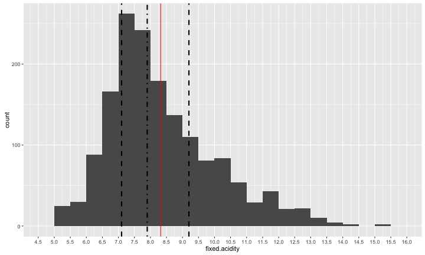

## Sulphates

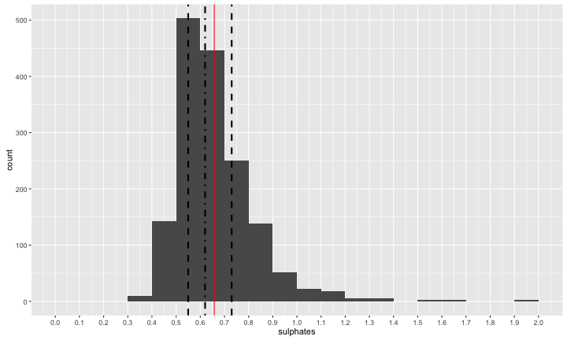

Most wines have sulphates between 0.4 and 0.9*g*/*d**m*<sup>3</sup>.

# Univariate Analysis

### What is the structure of your dataset?

There are 1599 different wines with 13 variables, including column X, which is just an index variable.

The 13 columns in this dataset are the following:

- X
- fixed.acidity
- volatile.acidity
- citric.acid
- residual.sugar
- chlorides
- free.sulfur.dioxide
- total.sulfur.dioxide
- density
- pH
- sulphates
- alcohol
- quality

They are all numeric

### What is/are the main feature(s) of interest in your dataset?

The main feature of interest in this dataset is quality. It would also be interesting if there was a feature for price. Unfortunately, it is not easy identify which wine is being referred in data, and this information is not available.

### What other features in the dataset do you think will help support your investigation into your feature(s) of interest?

I am expecting that the chemical composition (fixed.acidity, volatile.acidity, citric.acid, residual.sugar, chlorides, free.sulfur.dioxide, total.sulfur.dioxide, sulphates, alcohol) of the wine have an impact in the quality of the wine.

I am also curious to see whether a good wine needs to have a high percentage of alcohol by volume. Or whether a good wine is correlated with the amount of sugar. Since sulphates are an additive I am expecting it to be lower in high quality wines.

### Did you create any new variables from existing variables in the dataset?

# Bivariate Plots Section

```r
##                      fixed.acidity volatile.acidity citric.acid
## fixed.acidity           1.00000000     -0.256130895  0.67170343
## volatile.acidity       -0.25613089      1.000000000 -0.55249568
## citric.acid             0.67170343     -0.552495685  1.00000000
## residual.sugar          0.11477672      0.001917882  0.14357716
## chlorides               0.09370519      0.061297772  0.20382291
## free.sulfur.dioxide    -0.15379419     -0.010503827 -0.06097813
## total.sulfur.dioxide   -0.11318144      0.076470005  0.03553302
## density                 0.66804729      0.022026232  0.36494718
## pH                     -0.68297819      0.234937294 -0.54190414
## sulphates               0.18300566     -0.260986685  0.31277004
## alcohol                -0.06166827     -0.202288027  0.10990325
## quality                 0.12405165     -0.390557780  0.22637251
##                      residual.sugar    chlorides free.sulfur.dioxide
## fixed.acidity           0.114776724  0.093705186        -0.153794193
## volatile.acidity        0.001917882  0.061297772        -0.010503827
## citric.acid             0.143577162  0.203822914        -0.060978129
## residual.sugar          1.000000000  0.055609535         0.187048995
## chlorides               0.055609535  1.000000000         0.005562147
## free.sulfur.dioxide     0.187048995  0.005562147         1.000000000
## total.sulfur.dioxide    0.203027882  0.047400468         0.667666450
## density                 0.355283371  0.200632327        -0.021945831
## pH                     -0.085652422 -0.265026131         0.070377499
## sulphates               0.005527121  0.371260481         0.051657572
## alcohol                 0.042075437 -0.221140545        -0.069408354
## quality                 0.013731637 -0.128906560        -0.050656057
##                      total.sulfur.dioxide     density          pH
## fixed.acidity                 -0.11318144  0.66804729 -0.68297819
## volatile.acidity               0.07647000  0.02202623  0.23493729
## citric.acid                    0.03553302  0.36494718 -0.54190414
## residual.sugar                 0.20302788  0.35528337 -0.08565242
## chlorides                      0.04740047  0.20063233 -0.26502613
## free.sulfur.dioxide            0.66766645 -0.02194583  0.07037750
## total.sulfur.dioxide           1.00000000  0.07126948 -0.06649456
## density                        0.07126948  1.00000000 -0.34169933
## pH                            -0.06649456 -0.34169933  1.00000000
## sulphates                      0.04294684  0.14850641 -0.19664760
## alcohol                       -0.20565394 -0.49617977  0.20563251
## quality                       -0.18510029 -0.17491923 -0.05773139
##                         sulphates     alcohol     quality
## fixed.acidity         0.183005664 -0.06166827  0.12405165
## volatile.acidity     -0.260986685 -0.20228803 -0.39055778
## citric.acid           0.312770044  0.10990325  0.22637251
## residual.sugar        0.005527121  0.04207544  0.01373164
## chlorides             0.371260481 -0.22114054 -0.12890656
## free.sulfur.dioxide   0.051657572 -0.06940835 -0.05065606
## total.sulfur.dioxide  0.042946836 -0.20565394 -0.18510029
## density               0.148506412 -0.49617977 -0.17491923
## pH                   -0.196647602  0.20563251 -0.05773139
## sulphates             1.000000000  0.09359475  0.25139708
## alcohol               0.093594750  1.00000000  0.47616632
## quality               0.251397079  0.47616632  1.00000000
```

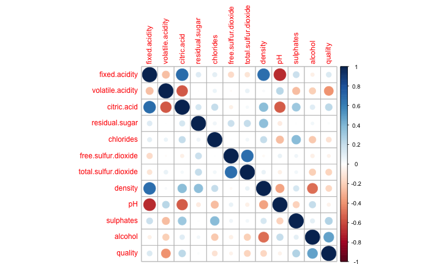

The only features that have correlation with quality are alcohol (0.476) and volatile.acidity (-0.391). The positive correlation with alcohol is really interesting.

Although I suggested that sulphates could be negatively correlated with quality, it is not evident in this analysis.

The following sections provide scatter plots of quality with other variables.

## Quality vs. Alcohol

```r
##
##  Pearson's product-moment correlation
##
## data:  df$alcohol and df$quality
## t = 21.639, df = 1597, p-value < 2.2e-16
## alternative hypothesis: true correlation is not equal to 0
## 95 percent confidence interval:
##  0.4373540 0.5132081
## sample estimates:
##       cor
## 0.4761663
```

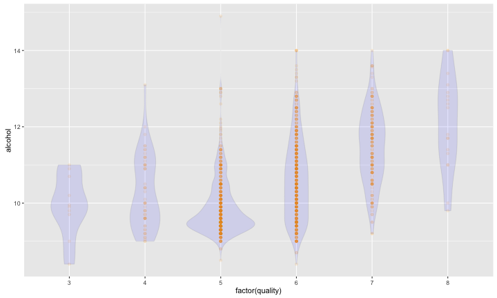

## Quality vs. Volatile Acidity

```r
##
##  Pearson's product-moment correlation
##
## data:  df$volatile.acidity and df$quality
## t = -16.954, df = 1597, p-value < 2.2e-16
## alternative hypothesis: true correlation is not equal to 0
## 95 percent confidence interval:
##  -0.4313210 -0.3482032
## sample estimates:
##        cor
## -0.3905578
```

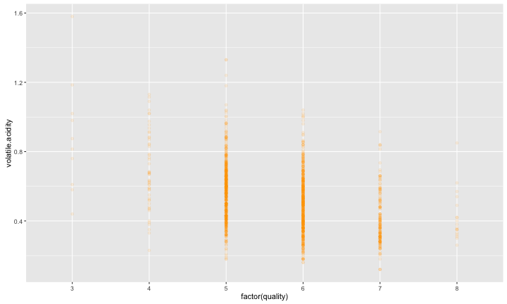

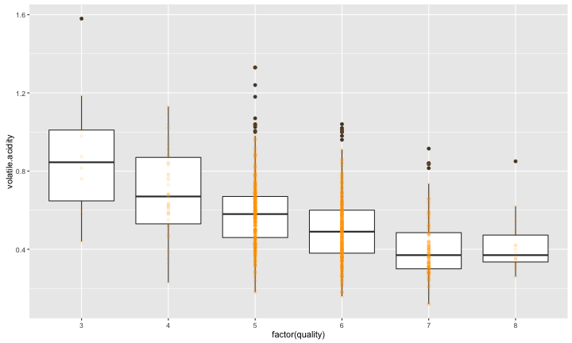

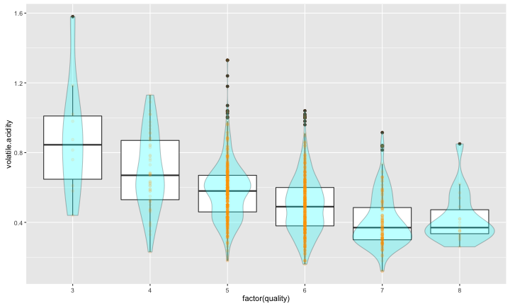

## Other interesting relationships

### Density vs. Fixed Acidity

```r
##
##  Pearson's product-moment correlation
##
## data:  df$density and df$fixed.acidity
## t = 35.877, df = 1597, p-value < 2.2e-16
## alternative hypothesis: true correlation is not equal to 0
## 95 percent confidence interval:
##  0.6399847 0.6943302
## sample estimates:
##       cor
## 0.6680473
```

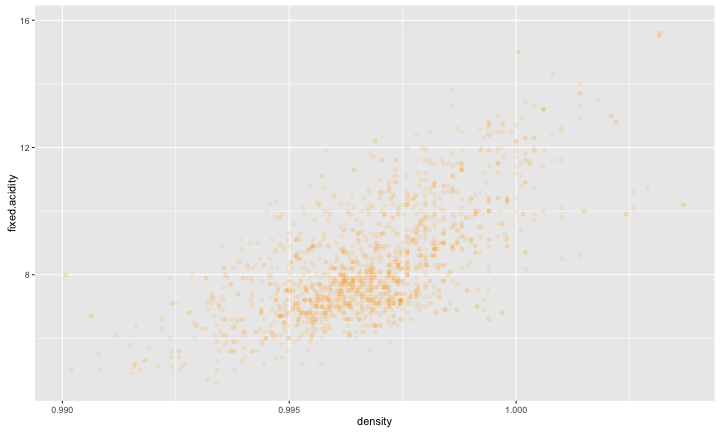

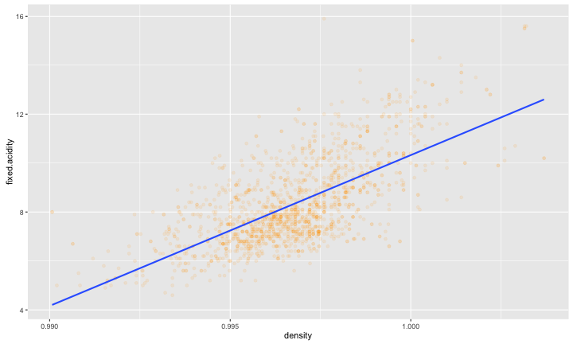

# Bivariate Analysis

### Talk about some of the relationships you observed in this part of the investigation. How did the feature(s) of interest vary with other features in the dataset?

The quality in this dataset presents positive correlation with alcohol (0.476) and a negative correlation with volatile acidity.

The positive correlation with alcohol is interesting. Perhaps more knowledge about this kind of wine is needed to explain this relationship.

The negative correlation with volatile acidity is in line with the fact that high levels of volatile acidity concentration give a vinegar taste to the wine.

### Did you observe any interesting relationships between the other features (not the main feature(s) of interest)?

There are in fact some other relationships but none seem to add interesting information in our problem.

Density is negatively correlated with alcohol. But that was already expected, since alcohol has lower density than water (yes, wine has water in its composition :-)).

Citric acid is correlated with fixed acidity, which is expected since citric acid is a fixed acid.

### What was the strongest relationship you found?

The strongest relation was between pH and fixed acidity ($− 0.682$). pH measures the acidity of the wine. Since the acidity is given by fixed acidity and volatile acidity the sum of both is expected to be highly correlated with pH. Volatile acidity does not have much impact on pH since its values are much lower when compared to fixed acidity, as it was shown above in the summary of the dataset (median for fixed acidity is $7.90$ and while for volatile acidity is $0.52$).

This is interesting because although volatile acidity is negatively correlated with the quality, it is not recognizable by the acidity of the wine.

# Multivariate Plots Section

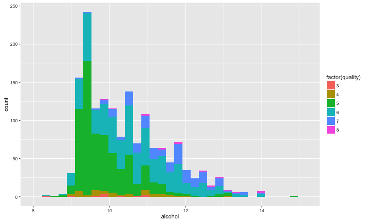

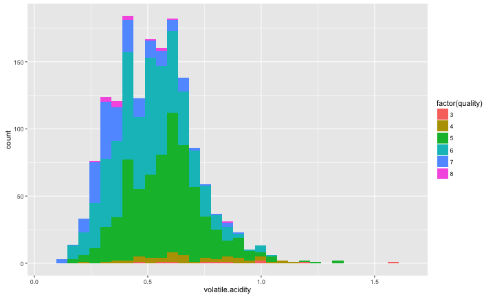

The plots with higher absolute correlation with quality are volatile.acidity and alcohol. The following plots investigate this relationship.

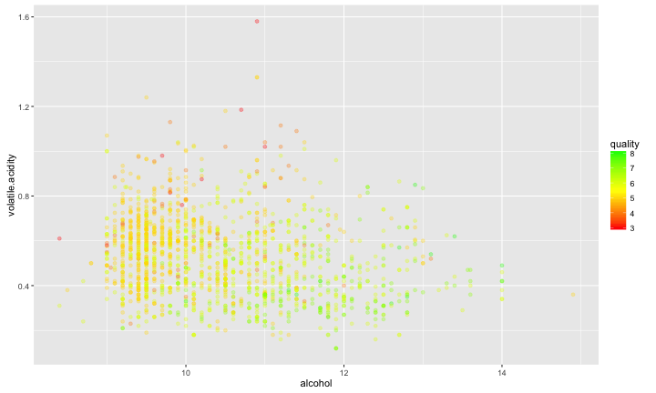

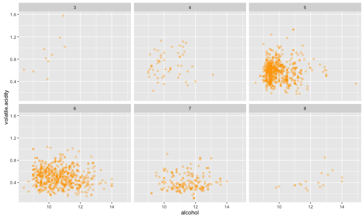

This last plot shows that for quality levels 5 and 6 the points are spread by a large region. Plots for the other quality levels show that there is a distinct pattern.

Perhaps combining the quality into 3 categories might help:

- Low: 3,4
- Mid: 5,6
- High: 7,8

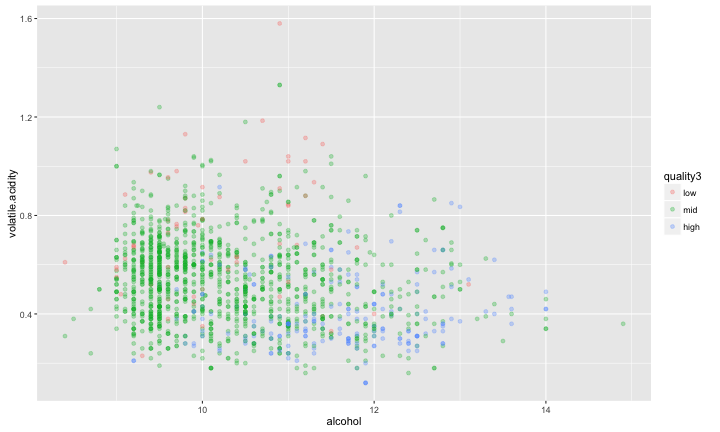

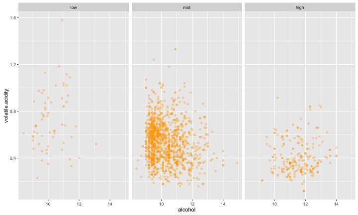

It did not help much, but it shows that low quality wines can be found spread in a wide region. Let's go back to the quality variable analysis and try to add a fourth variable.

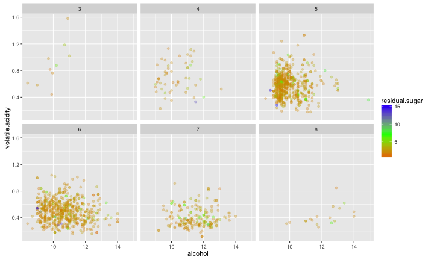

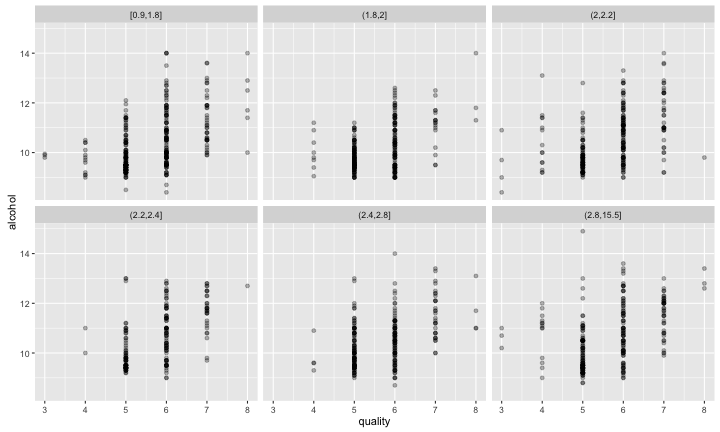

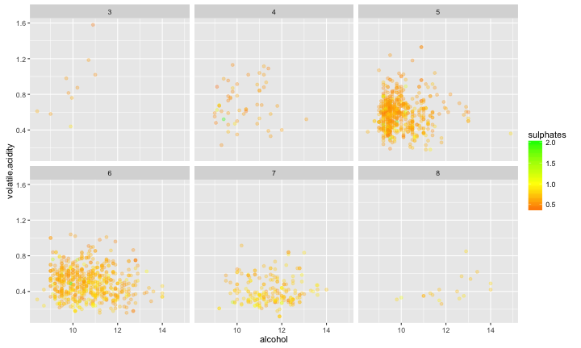

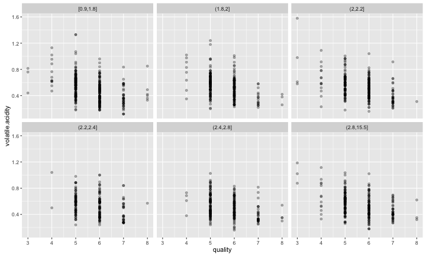

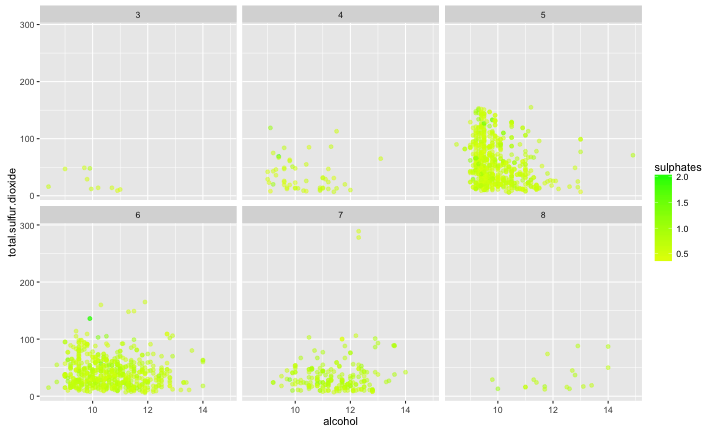

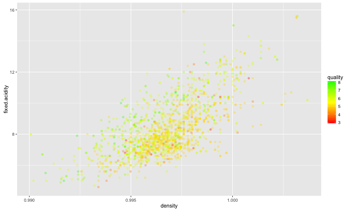

This last plot shows an interesting relationship. We can see that zones with lower density combined with higher fixed.acidity have more green dots.

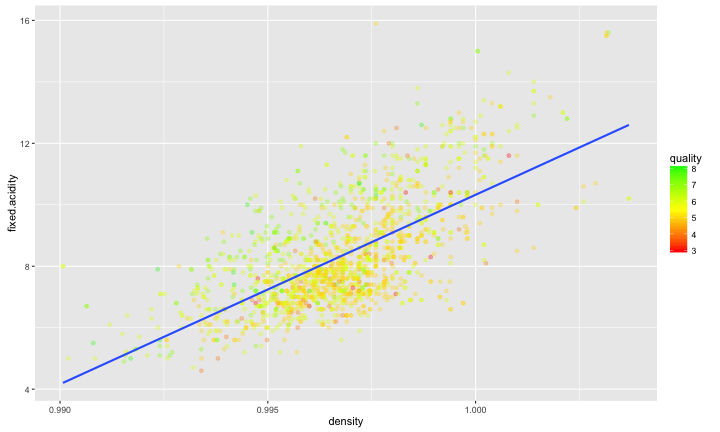

The blue line is the rect line that better fits the data. The error of this line shows some correlation with the quality of the wine. Perhaps rects with different slopes might make a better distinction of this interaction. For the purpose of this visualization, this is good enough.

**Note:** here the chosen color scheme is continuous and going from red for low quality, passing through yellow for medium quality and finally to green for high quality. The ordering in this color scheme should be easy to understand since we are familiar with the same scheme in other examples, for instance in "danger scales". The reason why a dual color scheme is not used is because these points are not opaque and the quality information can be easily mixed with the count of points in that region.

## Linear Regression

It might be interesting to fit a linear model in this data.

### Linear Regression with all features

```r
##
## Call:
## lm(formula = quality ~ fixed.acidity + volatile.acidity + citric.acid +
##     residual.sugar + chlorides + free.sulfur.dioxide + total.sulfur.dioxide +
##     density + pH + sulphates + alcohol, data = df)
##
## Residuals:
##      Min       1Q   Median       3Q      Max
## -2.68911 -0.36652 -0.04699  0.45202  2.02498
##
## Coefficients:
##                        Estimate Std. Error t value Pr(>|t|)
## (Intercept)           2.197e+01  2.119e+01   1.036   0.3002
## fixed.acidity         2.499e-02  2.595e-02   0.963   0.3357
## volatile.acidity     -1.084e+00  1.211e-01  -8.948  < 2e-16 ***
## citric.acid          -1.826e-01  1.472e-01  -1.240   0.2150
## residual.sugar        1.633e-02  1.500e-02   1.089   0.2765
## chlorides            -1.874e+00  4.193e-01  -4.470 8.37e-06 ***
## free.sulfur.dioxide   4.361e-03  2.171e-03   2.009   0.0447 *
## total.sulfur.dioxide -3.265e-03  7.287e-04  -4.480 8.00e-06 ***
## density              -1.788e+01  2.163e+01  -0.827   0.4086
## pH                   -4.137e-01  1.916e-01  -2.159   0.0310 *
## sulphates             9.163e-01  1.143e-01   8.014 2.13e-15 ***
## alcohol               2.762e-01  2.648e-02  10.429  < 2e-16 ***
## ---
## Signif. codes:  0 '***' 0.001 '**' 0.01 '*' 0.05 '.' 0.1 ' ' 1
##
## Residual standard error: 0.648 on 1587 degrees of freedom
## Multiple R-squared:  0.3606, Adjusted R-squared:  0.3561
## F-statistic: 81.35 on 11 and 1587 DF,  p-value: < 2.2e-16
```

### Linear Regression with Alcohol and Volatile Acidity

```r
##
## Call:
## lm(formula = quality ~ volatile.acidity + alcohol, data = df)
##
## Residuals:
##      Min       1Q   Median       3Q      Max
## -2.59342 -0.40416 -0.07426  0.46539  2.25809
##
## Coefficients:
##                  Estimate Std. Error t value Pr(>|t|)
## (Intercept)       3.09547    0.18450   16.78   <2e-16 ***
## volatile.acidity -1.38364    0.09527  -14.52   <2e-16 ***
## alcohol           0.31381    0.01601   19.60   <2e-16 ***
## ---
## Signif. codes:  0 '***' 0.001 '**' 0.01 '*' 0.05 '.' 0.1 ' ' 1
##
## Residual standard error: 0.6678 on 1596 degrees of freedom
## Multiple R-squared:  0.317,  Adjusted R-squared:  0.3161
## F-statistic: 370.4 on 2 and 1596 DF,  p-value: < 2.2e-16
```

### Linear Regression with Alcohol, Volatile Acidity, Fixed Acidity and Density

```r
##
## Call:
## lm(formula = quality ~ volatile.acidity + alcohol + fixed.acidity +
##     density, data = df)
##
## Residuals:
##      Min       1Q   Median       3Q      Max
## -2.65872 -0.39655 -0.08467  0.46342  2.28471
##
## Coefficients:
##                   Estimate Std. Error t value Pr(>|t|)
## (Intercept)       15.57282   15.18747   1.025  0.30534
## volatile.acidity  -1.27188    0.10016 -12.698  < 2e-16 ***
## alcohol            0.31080    0.01986  15.646  < 2e-16 ***
## fixed.acidity      0.04512    0.01486   3.037  0.00243 **
## density          -12.92242   15.21424  -0.849  0.39581
## ---
## Signif. codes:  0 '***' 0.001 '**' 0.01 '*' 0.05 '.' 0.1 ' ' 1
##
## Residual standard error: 0.6654 on 1594 degrees of freedom
## Multiple R-squared:  0.3228, Adjusted R-squared:  0.3211
## F-statistic: 189.9 on 4 and 1594 DF,  p-value: < 2.2e-16
```

This did not lead to better results. This is probably due to the fact that it is not recommended to use correlated features as input in a linear regression model.

# Multivariate Analysis

### Talk about some of the relationships you observed in this part of the investigation. Were there features that strengthened each other in terms of looking at your feature(s) of interest?

The relationship between alcohol, volatile acidity and quality was confirmed in this section. This was already expaction from the correlation analysis.

### Were there any interesting or surprising interactions between features?

The most surprising interaction was the combination of the features density and fixed acidity to predict quality. This was really interesting and might help making a more accurate wine quality classifier.

### OPTIONAL: Did you create any models with your dataset? Discuss the strengths and limitations of your model.

Only linear models were created. It was achieved a *R*<sup>2</sup> of 0.317 using only volatile.acidity and alcohol. Although this results are promissing, deploying such a simple model can be dangerous since it may lead to the temptation of artificially reducing volatile.acidity and increasing alcohol by producers.

# Final Plots and Summary

### Plot One

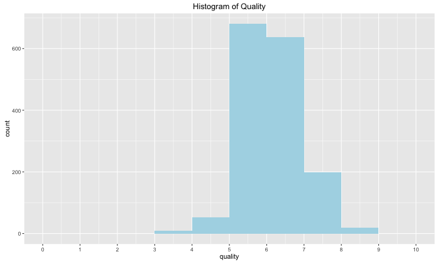

### Description One

This biased distribution has to be taken into account when evaluating a model to classify wine quality. The interest of having such a model is mostly to detect bad wines or good wines. Nevertheless, a low risk model that mostly classifies a wine as medium quality will have high scores due to this distribution.

### Plot Two

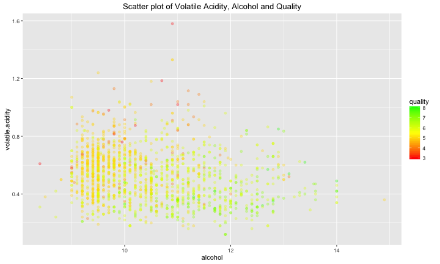

### Description Two

These are the features that revealed significant correlation with quality. Thus, the plot also shows the quality of each wine using a continuous color code. Red stands for low quality, yellow for medium quality and green for high quality.

The correlation of these features with quality is evident. It is possible to distinguish different regions according to the quality of the wine.

This plot shows the viability of creating a linear model using these 2 features to estimate the quality of wines "Vinho Verde". As seen previously in this document it is possible to fit a linear regression model with *R*<sup>2</sup> = 0.32.

### Plot Three

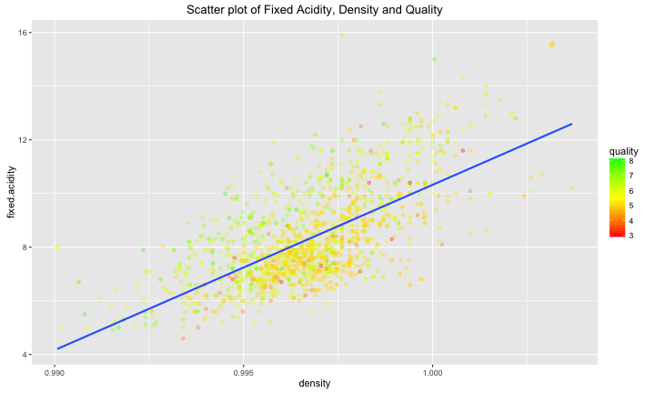

### Description Three

This scatter plot presents the correlation between fixed acidity and density. In the xx we have density which can go from 0.990 to 1.004. In the yy we have fixed acidity which can go from 4.60 to 15.90.

This plot also shows the quality of each wine using a continuous color code. Red stands for low quality, yellow for medium quality and green for high quality.

Finally, a linear regression line was added.

```r
##
## Call:
## lm(formula = fixed.acidity ~ density, data = df)
##
## Coefficients:
## (Intercept)      density
##      -606.0        616.3
```

Since fixed acidity and density have high correlation, this line is easy to figure. What makes this plot interesting is the fact that it shows that we can distinguish a region with more greens above this regression line, *y* = 616.3 * *x* − 606.0.

This means that it is possible to find a rect line in which the error with sign can be correlated with the quality of the wine.

# Reflection

The amount of sugar in the wine did not correlate with the quality. This is an important conslusion, since sweetness is usually an easy property to spot by beginners.

In this report, only linear models were used to fit data. Since the dataset has a good number of observations (1599), it might be interesting to try more complex machine learning algorithms.

The dataset used for this study was already clean and did not have non-valid values, which made the analysis a lot easier. Perhaps it would be interesting to have additional columns (e.g, price) to find new correlations. However, the authors did not disclose the name the wines in the dataset due to privacy reasons. This prevents from joining the dataset with other data that could provide interesting findings.

Another struggle in this problem is that usually wine is not evaluated using chemical properties. It is usally evaluated by sensitive properties, which although it is related with chemical properties, this relation is not that simple.

Finally, "Vinho Verde" wines can be made of different kinds of grapes (e.g, "Amaral", "Azal Tinto", "Borra??al", etc.). This information is not present in the dataset but perhaps different kinds of wines might have also different chemical composition regardless of quality.

Styled with knitrBootstrap